# Practical Machine Learning Final Project

P.W. Jacobus

1/31/2020

## Background

Using devices such as Jawbone Up, Nike FuelBand, and Fitbit it is now possible to collect a large amount of data about personal activity relatively inexpensively. These type of devices are part of the quantified self movement – a group of enthusiasts who take measurements about themselves regularly to improve their health, to find patterns in their behavior, or because they are tech geeks. One thing that people regularly do is quantify how much of a particular activity they do, but they rarely quantify how well they do it.

In this project, the goal is to use data from accelerometers on the belt, forearm, arm, and dumbbell of 6 participants. They were asked to perform barbell lifts correctly and incorrectly in 5 different ways. More information is available from the website here: http://web.archive.org/web/20161224072740/http:/groupware.les.inf.puc-rio.br/har (see the section on the Weight Lifting Exercise Dataset).

## Project Goal

The goal of the project is to predict the manner in which the participants did the exercise. This is the “classe” variable in the training set. Other variables may be used for prediction. The end result is to create a report describing the building of three models including cross validation, and expected sample error. The best model (highest accuracy) will be applied to the validation data of 20 sample sets for results to be used in the subsequent quiz.

## Load Libraries

```r
library(caret, warn.conflicts = FALSE, quietly=TRUE)
library(rattle, warn.conflicts = FALSE, quietly=TRUE)
library(randomForest, warn.conflicts = FALSE, quietly=TRUE)
```

```r
library(rpart, warn.conflicts = FALSE, quietly=TRUE)
library(corrplot, warn.conflicts = FALSE, quietly=TRUE)
```

## Load Data and Examine/Clean the Data

```r
train_orig <- read.csv('https://d396qusza40orc.cloudfront.net/predmachlearn/pml-training.csv', header = TRUE)
finalTest <- read.csv('https://d396qusza40orc.cloudfront.net/predmachlearn/pml-testing.csv', header = TRUE)
```

It is clear from observing this data that many observations have have near-zero variations, and some have all N/A values. Additionally, some observations do not add to the analysis (first seven columns) and can be eliminated. Eliminating the NZV and N/A variables as well as the first seven columns will result in a much smaller data set.

```r
## Cleaning the data
nearZero <- nearZeroVar(train_orig)
trainData <- train_orig[, -nearZero]
allNA <- colSums(is.na(trainData)) != 0
trainData <- trainData[, !allNA]
trainData <- trainData[, -c(1:7)]
```

The next step is splitting the data set in the standard 70/30% ratio between training and test data.

```r
## Splitting the Training data into train and test data sets
set.seed(1111)
masterTrain <- createDataPartition(trainData$classe, p=0.7, list=FALSE)
training <- trainData[masterTrain,]
testing <- trainData[-masterTrain,]
```

## Examining Correlation

A brief look at variable correlations will highlight how coupled the predictors are.

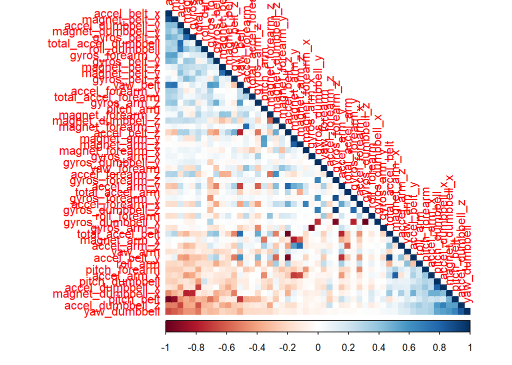

```r
correlationMatrix <- cor(training[, -52])
corrplot(correlationMatrix, order = "FPC", method = "color", type="lower")
```

## Prediction Modeling

Per the course project guidelines, three models will be built and applied to the training dataset. The one with the highest accuracy of prediction using the testing dataset will be used for the final prediction using the the validation (finalTest) dataset. The three models will be Classification Tree, Random Forest, and the Gradient Boosting Models. Confusion matrices will be presented to show demonstrate the accuracy of the models against all of the factors.

For cross-validation of the data, the k-fold cross validation method will be used for splitting the data into k-subsets. For the size of k, the R documentation suggest values of 3-10, so 5 is chosen as a reasonable value.

```r
trControlValues <- trainControl(method="cv", number=5)
```

### Classification Tree Model

```r
## Fitting the model
CT_model <- train(classe~., data=training, method="rpart", trControl=trControlValues)
## Looking into the model
CT_model$finalModel
```

```
## n= 13737
##
## node), split, n, loss, yval, (yprob)
##       * denotes terminal node
##
##   1) root 13737 9831 A (0.28 0.19 0.17 0.16 0.18)
##     2) pitch_forearm< -33.95 1087    7 A (0.99 0.0064 0 0 0) *
##     3) pitch_forearm>=-33.95 12650 9824 A (0.22 0.21 0.19 0.18 0.2)
##       6) accel_belt_z>=-187.5 11923 9099 A (0.24 0.22 0.2 0.19 0.15)
##        12) yaw_belt>=169.5 573   64 A (0.89 0.052 0 0.052 0.007) *
##        13) yaw_belt< 169.5 11350 8730 B (0.2 0.23 0.21 0.2 0.16)
##          26) magnet_dumbbell_z< -88.5 1418  616 A (0.57 0.28 0.045 0.075 0.032) *
##          27) magnet_dumbbell_z>=-88.5 9932 7600 C (0.15 0.22 0.23 0.21 0.18)
##            54) pitch_belt< -42.95 589  104 B (0.022 0.82 0.093 0.025 0.036) *
##            55) pitch_belt>=-42.95 9343 7066 C (0.16 0.19 0.24 0.22 0.19)
##             110) magnet_dumbbell_y< 292.5 4111 2494 C (0.19 0.11 0.39 0.16 0.15) *
##             111) magnet_dumbbell_y>=292.5 5232 3793 D (0.14 0.24 0.13 0.28 0.22)
##               222) accel_dumbbell_y>=-45.5 4712 3288 D (0.16 0.26 0.062 0.3 0.22)
##                 444) accel_forearm_x>=-93.5 2531 1722 B (0.18 0.32 0.093 0.12 0.28) *
##                 445) accel_forearm_x< -93.5 2181 1069 D (0.12 0.2 0.026 0.51 0.14)
##                   890) accel_dumbbell_z>=32.5 355  103 B (0.025 0.71 0 0.099 0.17) *
##                   891) accel_dumbbell_z< 32.5 1826  749 D (0.14 0.1 0.031 0.59 0.14) *
##               223) accel_dumbbell_y< -45.5 520  152 C (0 0.048 0.71 0.029 0.22) *
##       7) accel_belt_z< -187.5 727    3 E (0.0028 0.0014 0 0 1) *
```

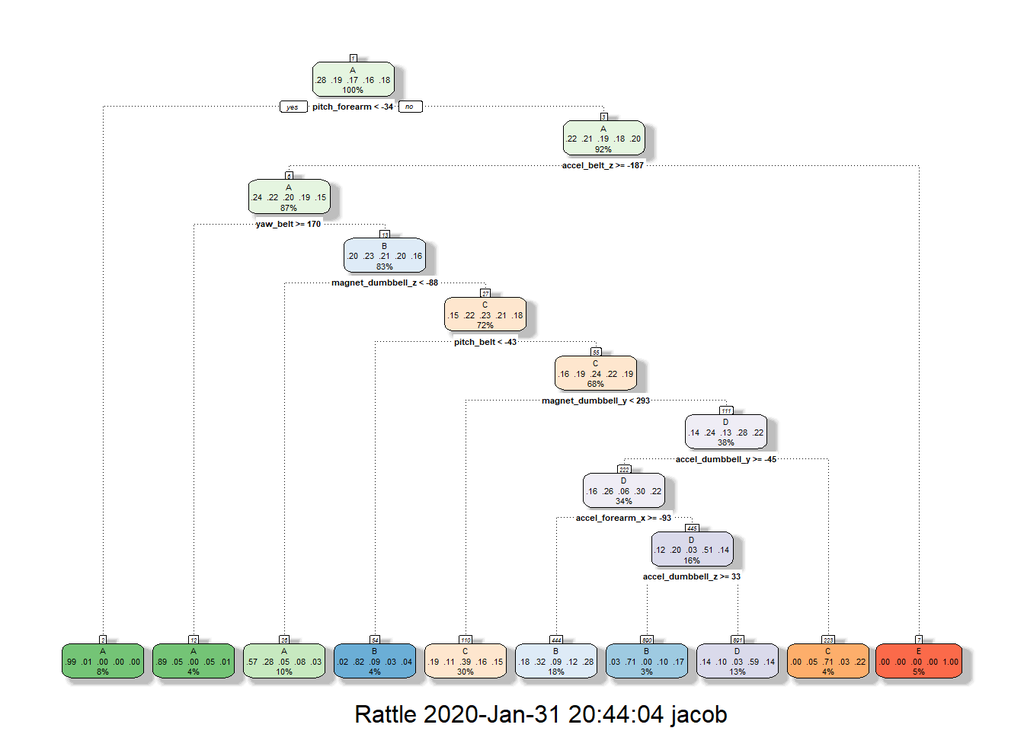

```r
fancyRpartPlot(CT_model$finalModel)
```

```r
## Predicting on the Test dataset
CT_pred <- predict(CT_model, newdata = testing)
CT_confusion <- confusionMatrix(CT_pred, testing$classe)
CT_confusion$table
```

```
##           Reference
## Prediction    A    B    C    D    E
##          A 1043  181   34   50   15
##          B  214  690  127  158  333
##          C  323  200  842  279  313
##          D   90   68   23  477  117
##          E    4    0    0    0  304
```

```r
CT_confusion$overall['Accuracy']
```

```
##  Accuracy
## 0.5702634
```

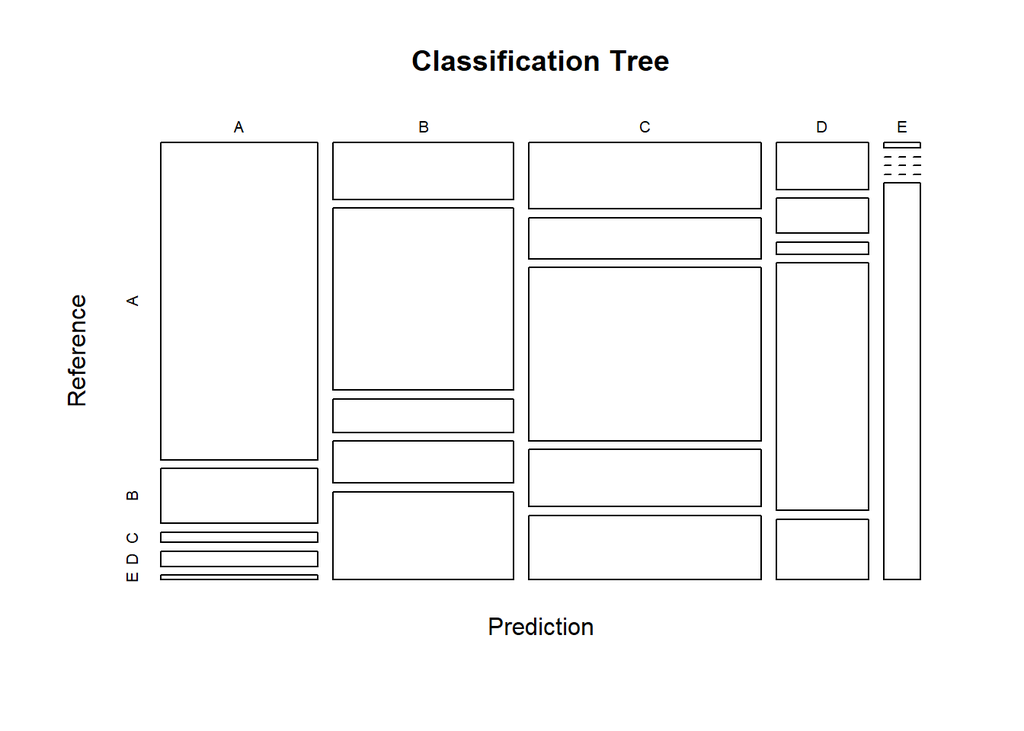

```r
## Plot Accuracy results by factor
plot(CT_confusion$table, col=CT_confusion$byClass, main="Classification Tree")
```

The accuracy of the Classification Tree is approximately 0.57, which appears to be fairly low. The sample error is approximately 0.43.

### Random Forest Model

```r
## Fitting the model
RF_model <- train(classe~., data=training, method="rf", trControl=trControlValues)
## Looking into the model
RF_model$finalModel
```

```
##
## Call:
##  randomForest(x = x, y = y, mtry = param$mtry)
##                Type of random forest: classification
##                      Number of trees: 500
## No. of variables tried at each split: 26
##
##         OOB estimate of  error rate: 0.74%
## Confusion matrix:
##      A    B    C    D    E class.error
## A 3898    5    1    0    2 0.002048131
## B   18 2629    9    1    1 0.010910459
## C    0   16 2370    9    1 0.010851419
## D    0    0   25 2223    4 0.012877442
## E    0    0    4    6 2515 0.003960396
```

```r
## Predicting on the Test dataset
RF_pred <- predict(RF_model, newdata = testing)
RF_confusion <- confusionMatrix(RF_pred, testing$classe)
RF_confusion$table
```

```
##           Reference
## Prediction    A    B    C    D    E
##          A 1672    7    0    0    0
##          B    1 1130    5    0    0
##          C    1    1 1017    4    1
##          D    0    0    4  960    0
##          E    0    1    0    0 1081
```

```r
RF_confusion$overall['Accuracy']
```

```
##  Accuracy
## 0.9957519
```

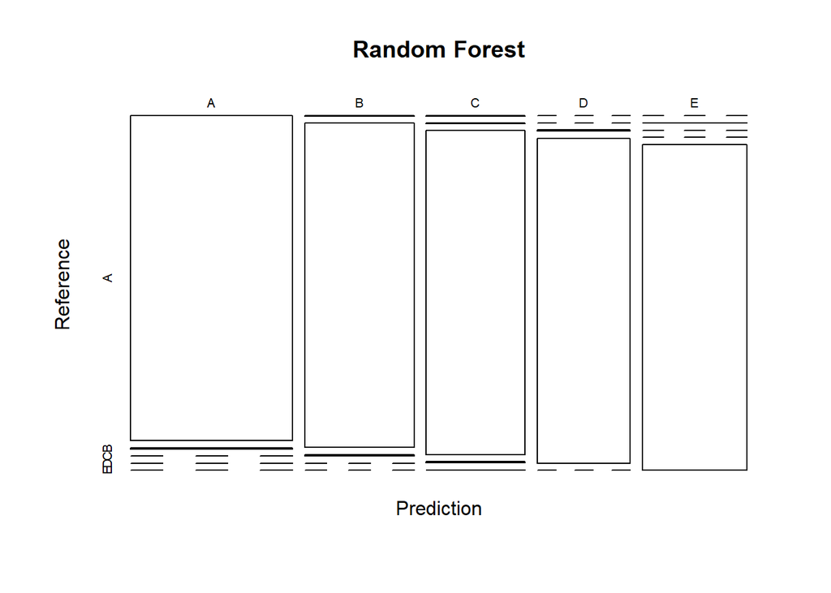

```r
## Plot Accuracy results by factor
plot(RF_confusion$table, col=RF_confusion$byClass, main="Random Forest")
```

### Gradient Boosting Model

```r
## Fitting the model
GBM_model <- train(classe~., data=training, method="gbm", trControl=trControlValues, verbose = FALSE)
## Looking into the model
GBM_model$finalModel
```

```
## A gradient boosted model with multinomial loss function.
## 150 iterations were performed.
## There were 51 predictors of which 51 had non-zero influence.
```

```r
## Predicting on the Test dataset
GBM_pred <- predict(GBM_model, newdata = testing)
GBM_confusion <- confusionMatrix(GBM_pred, testing$classe)
GBM_confusion$table
```

```
##           Reference
## Prediction    A    B    C    D    E
##          A 1639   31    0    3    1
##          B   22 1074   32    4    6
##          C   10   31  976   28   15
##          D    2    2   15  918   13
##          E    1    1    3   11 1047
```

```r
GBM_confusion$overall['Accuracy']
```

```
##  Accuracy
## 0.9607477
```

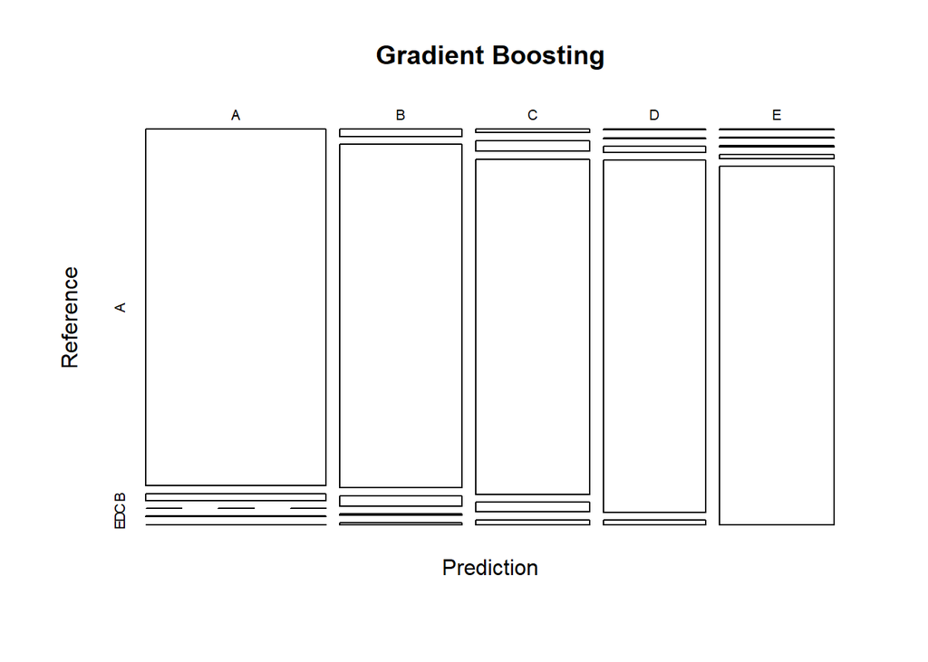

```r
## Plot Accuracy results by factor
plot(GBM_confusion$table, col=GBM_confusion$byClass, main="Gradient Boosting")
```

## Best Model

The accuracy of the Random Forest was the highest, by several percentage points. Using this model on the validation data yields:

```r
finalResult <- predict(RF_model, newdata= finalTest)
finalResult
```

```
##  [1] B A B A A E D B A A B C B A E E A B B B
## Levels: A B C D E
```

These results will be used in the subsequent quiz.